# TK_61: Rerun of RNAseq and RIBOseq datasets from samples induced with 2-5A/polyI:C

Hernan Lorenzi

7/17/2023

**PI:** Nick Guydosh  
**Point of Contact:** Agnes Karasik  
**Contact email:** agnes.karasik@nih.gov

**Summary:** The goal of this project is to recalculate Log2FC for RNAseq and RIBOseq datasets from samples induced with 2-5A/polyI:C, using read-count tables based on exon or CDS features.

### Results

[Link to filtered differential expression tables with shrinkage](https://nih.sharepoint.com/:f:/r/sites/NIDDK-GuydoshLab/Shared%20Documents/TK_61/Results/DE_with_filter?csf=1&web=1&e=5hlvbT)

[Link to unfiltered differential expression tables with shrinkage](https://nih.sharepoint.com/:f:/r/sites/NIDDK-GuydoshLab/Shared%20Documents/TK_61/Results/DE_unfiltered_shrinkage?csf=1&web=1&e=sr35Og)

[Link to unfiltered differential expression tables with no shrinkage](https://nih.sharepoint.com/:f:/r/sites/NIDDK-GuydoshLab/Shared%20Documents/TK_61/Results/DE_unfiltered_no_shrinkage?csf=1&web=1&e=FcWdKh)

| File | Contrast | Feature | Data source |
| --- | --- | --- | --- |
| DE_wtIC_vs_wtNone_cds.txt | WT - pIC vs Control | CDS | RNAseq |
| DE_koIC_vs_koNone_cds.txt | KO - pIC vs Control | CDS | RNAseq |
| DE_wt25A_vs_wtNone_cds.txt | WT - 2-5A vs Control | CDS | RNAseq |
| DE_ko25A_vs_koNone_cds.txt | KO - 2-5A vs Control | CDS | RNAseq |
| DE_wtIC_vs_wtNone_exon.txt | WT - pIC vs Control | Exon | RNAseq |
| DE_koIC_vs_koNone_exon.txt | KO - pIC vs Control | Exon | RNAseq |
| DE_wt25A_vs_wtNone_exon.txt | WT - 2-5A vs Control | Exon | RNAseq |
| DE_ko25A_vs_koNone_exon.txt | KO - 2-5A vs Control | Exon | RNAseq |
| DE_wtIC_vs_wtNone_RS.txt | WT - pIC vs Control | CDS | RIBOseq |
| DE_koIC_vs_koNone_RS.txt | KO - pIC vs Control | CDS | RIBOseq |
| DE_wt25A_vs_wtNone_RS.txt | WT - 2-5A vs Control | CDS | RIBOseq |
| DE_ko25A_vs_koNone_RS.txt | KO - 2-5A vs Control | CDS | RIBOseq |

[Link to exploratory plots](https://nih.sharepoint.com/:f:/r/sites/NIDDK-GuydoshLab/Shared%20Documents/TK_61/Results/Plots?csf=1&web=1&e=StjukZ)

| File | Contrast | Feature | Data source |
| --- | --- | --- | --- |
| barplot_read_counts_cds.pdf | Read counts per sample | CDS | RNAseq |
| pca_dataset_1_Induc_gt_cds.pdf | PCA colored by genotype | CDS | RNAseq |
| pca_dataset_1_Induc_read_counts_cds.pdf | PCA colored by sequencing depth | CDS | RNAseq |
| barplot_read_counts_exon.pdf | Read counts per sample | Exon | RNAseq |
| pca_dataset_1_Induc_gt_exon.pdf | PCA colored by genotype | Exon | RNAseq |
| pca_dataset_1_Induc_read_counts_exon.pdf | PCA colored by sequencing depth | Exon | RNAseq |
| barplot_read_counts_RS.pdf | Read counts per sample | CDS | RIBOseq |
| pca_dataset_1_Induc_gt_RS.pdf | PCA colored by genotype | CDS | RIBOseq |
| pca_dataset_1_Induc_read_counts_RS.pdf | PCA colored by sequencing depth | CDS | RIBOseq |

[Link to github repository](https://github.com/TriLab-bioinf/GOYDOSH_LAB_TK_61)

### Load libraries

```r
suppressMessages(library("org.Hs.eg.db"))
suppressMessages(library("pheatmap"))
#suppressMessages(library("EnhancedVolcano"))
suppressMessages(library("ggplot2"))
suppressMessages(library("ggpubr"))
suppressMessages(library("DESeq2"))
suppressMessages(library("stringr"))
suppressMessages(library("biomaRt"))
#suppressMessages(library("tidyverse"))
suppressMessages(library("pcaExplorer"))
#suppressMessages(library("clusterProfiler"))
suppressMessages(library("ggsci"))
suppressMessages(library("viridis"))
#suppressMessages(library("ggrepel"))
suppressMessages(library("RColorBrewer"))
#suppressMessages(library("msigdbr"))
suppressMessages(library("cowplot"))
#suppressMessages(library("enrichplot"))
#suppressMessages(library("ggupset"))
#suppressMessages(library("ggraph"))
```

### Upload required functions

```r
# Load auxyliary functions
source(file = "./01_aux_rnaseq_functions.R")

# Load enrichment functions
source(file = "./02_Gene_enrichment_functions.R")
```

## CDS counts

### Load RNAseq CDS data

```r
all <- read.delim2("./data/cdsrna_round.csv", sep = ",", header = TRUE, row.names = 1, comment.char = c("#"))

# Keep table with Ensemble IDs and gene Symbols
gene_symbols <- replace_gene_acc_by_symbol_ids(rownames(all))
ensembl_to_symbol <- as.data.frame(cbind("Ensembl_ID" = rownames(all), "gene_name" = gene_symbols), row.names = 1)

# Load metadata
metadata <- read.delim2("./data/Metadata.txt", sep = "\t", row.names = 1, header = T)

# keep only samples that are present in all
metadata <- metadata[colnames(all),]

# Add total read counts and sample id columns to metadata
metadata <- cbind(metadata, Read_counts =colSums(all), Sample_id = rownames(metadata))

# Agnes wanted to keep all genes in the analysis, including all 0 genes
#Remove all zero rows
# all <- remove_all_zero_rows(all, min_total_count = 0)
```

### Analysis of expression data using DESeq2 - CDS

```r
# Convert metadata to factors
for (variable in c("Sequencing_pool", "Read_length","Machine", "Genotype","Group",  "Colection_time",   "X25A", "PolyIC",   "Triptolyde",   "CHX",  "Puromycin",    "Dataset",  "Inducer",  "Treatment" )){
  metadata[,variable] <- as.factor(metadata[,variable])
}

# Subset metadata and count tables by Data
meta_one_cds <- subset(metadata, metadata$Dataset == "one")
all_one_cds <- all[, rownames(meta_one_cds)]
```

I created a new column in metadata (Group_gt_ind) that concatenates the info from Genotype and Inducer columns so coefficients include genotype info.

```r
dir.create(path = "./Plots", showWarnings = F)
dir.create(path = "./DE", showWarnings = F)

meta_one_cds$Group_gt_ind <- factor(paste0(meta_one_cds$Genotype, meta_one_cds$Inducer))
```

I also added a new column (Read_depth) to tag samples with High or Low sequencing depth so this factor can be controlled for in the design formula.

The design formula use in DESeq2 is the following:

```
design = ~ Read_depth + Group_gt_ind
```

```r
# add new factors (Group_gt_ind and Read_depth (high > 3M reads / Low < 3M reads) for CDS based counts)
meta_one_cds$Read_depth <- 'High'
meta_one_cds[meta_one_cds$Read_counts < 3e6,]$Read_depth <- 'Low'
meta_one_cds$Read_depth <- as.factor(meta_one_cds$Read_depth)

# Adding read_depth in design to control for read_depth
dds.one.cds <- DESeqDataSetFromMatrix(countData = all_one_cds,
                              colData = meta_one_cds,
                              design = ~ Read_depth + Group_gt_ind)
```

### Exploratory analysis with DESeq object- CDS

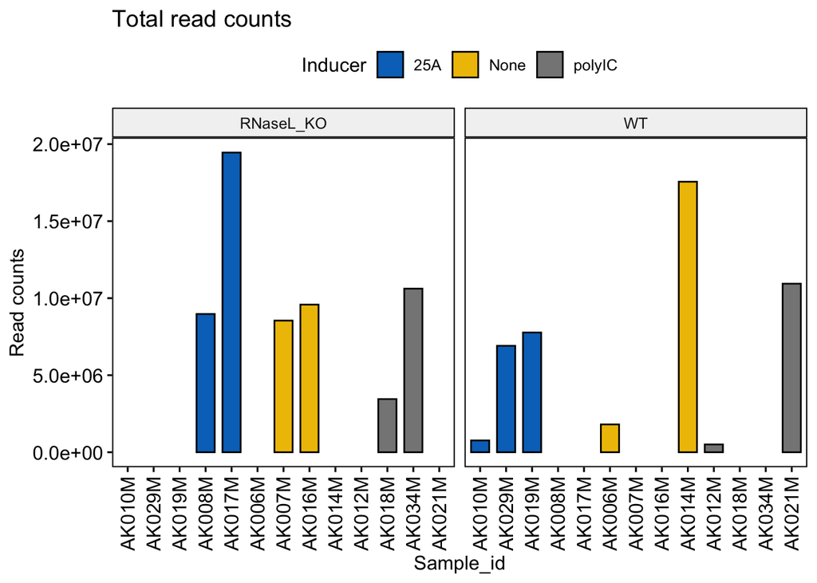

```r
# Plot total reads per sample using barchar
p <- ggbarplot(data = meta_one_cds,
          x = "Sample_id",
          y = "Read_counts",
          x.text.angle = 90,
          fill = "Inducer",
          title = "Total read counts",
          ylab = "Read counts",
          sort.by.groups = TRUE,
          palette = "jco",
          sort.val = "asc",
          facet.by = "Genotype")
ggsave("Plots/barplot_read_counts_cds.pdf", plot = p)
p
```

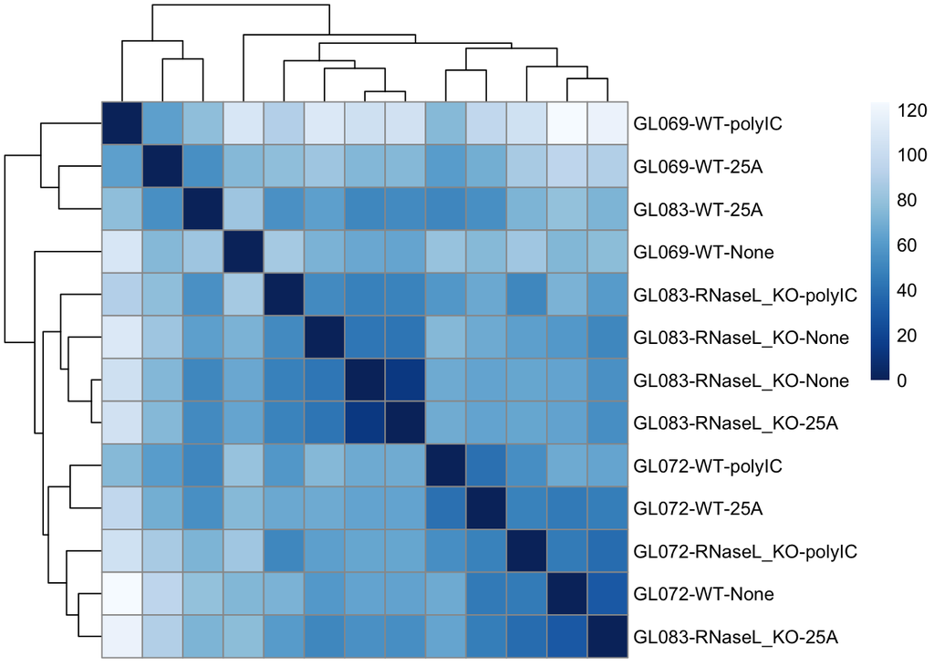

```r
# Normalize counts
rlog.one <- rlog(dds.one.cds, blind=FALSE)

# Keep genes with at least 0 reads total across samples
keep <- rowSums(counts(dds.one.cds)) >= 0 # Agnes wanted to keep all genes for the analysis
dds.one.cds <- dds.one.cds[keep,]

# Calculate distances between samples
sampleDists <- dist(t(assay(rlog.one)))

# Plot inter-sample distances
old.par <- par(no.readonly=T)

sampleDistMatrix <- as.matrix(sampleDists)
rownames(sampleDistMatrix) <- paste(rlog.one$Sequencing_pool, rlog.one$Genotype, rlog.one$Inducer, sep="-")
colnames(sampleDistMatrix) <- NULL
colors <- colorRampPalette( rev(brewer.pal(9, "Blues")) )(255)
pheatmap(sampleDistMatrix,
         clustering_distance_rows=sampleDists,
         clustering_distance_cols=sampleDists,
         col=colors)
```

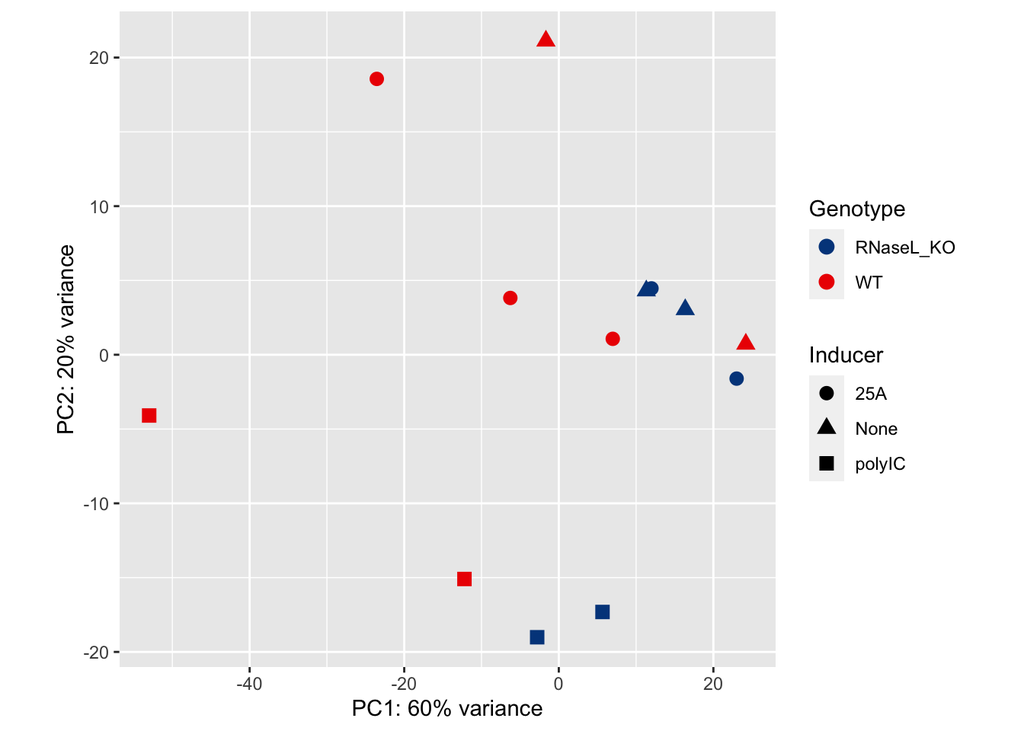

```r
# PCA
my_top_genes = 540

pcaData <- plotPCA(rlog.one, intgroup=c("Genotype", "Inducer"), returnData=TRUE, ntop = my_top_genes)
percentVar <- round(100 * attr(pcaData, "percentVar"))
y.coords = c(min(pcaData$PC1, pcaData$PC2), max(pcaData$PC1, pcaData$PC2))
x.coords = y.coords
p1 <- ggplot(pcaData, aes(PC1, PC2, color=Genotype, shape=Inducer)) +
  geom_point(size=3) + scale_color_lancet() +
  xlab(paste0("PC1: ",percentVar[1],"% variance")) +
  ylab(paste0("PC2: ",percentVar[2],"% variance")) +
  coord_fixed(ratio = (max(pcaData$PC1)-min(pcaData$PC1))/(max(pcaData$PC2)-min(pcaData$PC2)))

ggsave("Plots/pca_dataset_1_Induc_gt_cds.pdf", plot = p1)
p1
```

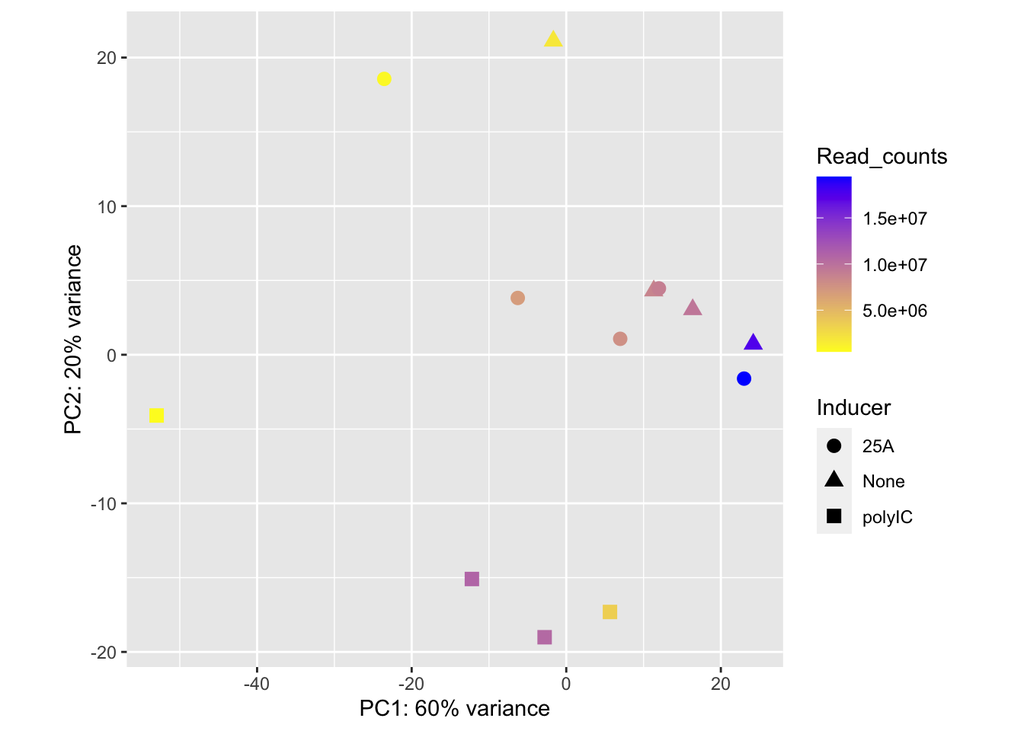

```r
pcaData <- plotPCA(rlog.one, intgroup=c("Read_counts", "Inducer"), returnData=TRUE, ntop = my_top_genes)
percentVar <- round(100 * attr(pcaData, "percentVar"))
p2 <- ggplot(pcaData, aes(PC1, PC2, color=Read_counts, shape=Inducer)) +
  geom_point(size=3) +
  xlab(paste0("PC1: ",percentVar[1],"% variance")) +
  ylab(paste0("PC2: ",percentVar[2],"% variance")) +
  coord_fixed(ratio = (max(pcaData$PC1)-min(pcaData$PC1))/(max(pcaData$PC2)-min(pcaData$PC2))) + scale_color_gradient2(high = "blue", mid = "yellow")

ggsave("Plots/pca_dataset_1_Induc_read_counts_cds.pdf", plot = p2)
p2
```

PCA plots indicate that samples separated on PC1 mostly by sequencing depth, within treatments and genotypes. This implies that sequencing depth has to be controlled for by including this factor in the design formula.

```r
# Keep genes with at least 10 reads total across samples
keep <- rowSums(counts(dds.one.cds)) >= 0 # Agnes wanted to keep all genes
dds.one.cds <- dds.one.cds[keep,]
```

### Spliting DESeq object based on genotype - CDS

```r
dds.one.cds.wt <- dds.one.cds[ , dds.one.cds$Genotype == "WT"]
dds.one.cds.wt$Genotype <- droplevels( dds.one.cds.wt$Genotype)
dds.one.cds.wt$Group_gt_ind <- droplevels( dds.one.cds.wt$Group_gt_ind)
dds.one.cds.wt$Group <- droplevels( dds.one.cds.wt$Group)

dds.one.cds.ko <- dds.one.cds[ , dds.one.cds$Genotype == "RNaseL_KO"]
dds.one.cds.ko$Genotype <- droplevels( dds.one.cds.ko$Genotype)
dds.one.cds.ko$Group_gt_ind <- droplevels( dds.one.cds.ko$Group_gt_ind)
dds.one.cds.ko$Group <- droplevels( dds.one.cds.ko$Group)
```

### Calculate differential expression for WT - CDS

```r
# Calculate DE for WT samples
dds.one.cds.wt$Group_gt_ind <- relevel(dds.one.cds.wt$Group_gt_ind, "WTNone")
dds.one.cds.wt <- DESeq(dds.one.cds.wt)
resultsNames(dds.one.cds.wt)
```

```
## [1] "Intercept"                       "Read_depth_Low_vs_High"
## [3] "Group_gt_ind_WT25A_vs_WTNone"    "Group_gt_ind_WTpolyIC_vs_WTNone"
```

```r
# Using results function instead of lfcShrink, as requested by Agnes
res_wtIC_vs_wtNone <- results(dds.one.cds.wt, list(c( "Group_gt_ind_WTpolyIC_vs_WTNone" )))
res_wt25A_vs_wtNone <- results(dds.one.cds.wt, list(c( "Group_gt_ind_WT25A_vs_WTNone")))


# Using lfcShrink instead of results to reduce high Log2FC bias of genes with low expression
# res_wtIC_vs_wtNone <- lfcShrink(dds.one.cds.wt, coef = "Group_gt_ind_WTpolyIC_vs_WTNone", type = "ashr", )
# res_wt25A_vs_wtNone <- lfcShrink(dds.one.cds.wt, coef = "Group_gt_ind_WT25A_vs_WTNone", type = "ashr")

summary(res_wtIC_vs_wtNone, alpha = 0.05)
```

```
##
## out of 17368 with nonzero total read count
## adjusted p-value < 0.05
## LFC > 0 (up)       : 1208, 7%
## LFC < 0 (down)     : 644, 3.7%
## outliers [1]       : 0, 0%
## low counts [2]     : 4973, 29%
## (mean count < 8)
## [1] see 'cooksCutoff' argument of ?results
## [2] see 'independentFiltering' argument of ?results
```

```r
summary(res_wt25A_vs_wtNone, alpha = 0.05)
```

```
##
## out of 17368 with nonzero total read count
## adjusted p-value < 0.05
## LFC > 0 (up)       : 730, 4.2%
## LFC < 0 (down)     : 225, 1.3%
## outliers [1]       : 0, 0%
## low counts [2]     : 7294, 42%
## (mean count < 35)
## [1] see 'cooksCutoff' argument of ?results
## [2] see 'independentFiltering' argument of ?results
```

### Calculate DE for KO samples - CDS

```r
dds.one.cds.ko$Group_gt_ind <- relevel(dds.one.cds.ko$Group_gt_ind, "RNaseL_KONone")
# Changing design formula given that there is no KO sample with Low read counts, otherwise you get an error message
design(dds.one.cds.ko) <- ~Group_gt_ind
dds.one.cds.ko <- DESeq(dds.one.cds.ko)
resultsNames(dds.one.cds.ko)
```

```
## [1] "Intercept"
## [2] "Group_gt_ind_RNaseL_KO25A_vs_RNaseL_KONone"
## [3] "Group_gt_ind_RNaseL_KOpolyIC_vs_RNaseL_KONone"
```

```r
# Using results function instead of lfcShrink, as requested by Agnes
res_koIC_vs_koNone <- results(dds.one.cds.ko, list(c( "Group_gt_ind_RNaseL_KOpolyIC_vs_RNaseL_KONone")))
res_ko25A_vs_koNone <- results(dds.one.cds.ko, list(c( "Group_gt_ind_RNaseL_KO25A_vs_RNaseL_KONone")))

# res_koIC_vs_koNone <- lfcShrink(dds.one.cds.ko, coef = "Group_gt_ind_RNaseL_KOpolyIC_vs_RNaseL_KONone", type = "ashr")
# res_ko25A_vs_koNone <- lfcShrink(dds.one.cds.ko, coef = "Group_gt_ind_RNaseL_KO25A_vs_RNaseL_KONone", type = "ashr")

summary(res_koIC_vs_koNone, alpha = 0.05)
```

[output not shown]

```r
summary(res_ko25A_vs_koNone, alpha = 0.05)
```

```
##
## out of 17051 with nonzero total read count
## adjusted p-value < 0.05
## LFC > 0 (up)       : 0, 0%
## LFC < 0 (down)     : 0, 0%
## outliers [1]       : 0, 0%
## low counts [2]     : 0, 0%
## (mean count < 0)
## [1] see 'cooksCutoff' argument of ?results
## [2] see 'independentFiltering' argument of ?results
```

### Write DE tables to file - CDS

```r
# Define function for processing and saving result tables
sort_and_write_res_table <- function(result_table, file_name){
  # Sort genes by (padj)
  result_table_sorted <- result_table[order(result_table$padj, decreasing = FALSE),]
  # Add gene symbols
  gene_list <- rownames(result_table_sorted)
  symbol_list <- ensembl_to_symbol$gene_name[match(gene_list, ensembl_to_symbol$Ensembl_ID)]
  df <-as.data.frame(cbind(result_table_sorted, Gene_name = symbol_list))

  # Write sorted table to file
  write.table(df, file = paste0("./DE/",file_name,".txt"),
            sep = "\t", col.names=NA)
  return(result_table_sorted)
}

# Sort results by Log2FC
res_wtIC_vs_wtNone.logfc_sorted <- sort_and_write_res_table(res_wtIC_vs_wtNone, "DE_wtIC_vs_wtNone_cds")
res_koIC_vs_koNone.logfc_sorted <- sort_and_write_res_table(res_koIC_vs_koNone, "DE_koIC_vs_koNone_cds")
res_wt25A_vs_wtNone.logfc_sorted <- sort_and_write_res_table(res_wt25A_vs_wtNone, "DE_wt25A_vs_wtNone_cds")
res_ko25A_vs_koNone.logfc_sorted <- sort_and_write_res_table(res_ko25A_vs_koNone, "DE_ko25A_vs_koNone_cds")

# Save sorted files as a list
DE_results = list()
DE_results[["wtIC_vs_wtNone_cds"]]  <- res_wtIC_vs_wtNone.logfc_sorted
DE_results[["koIC_vs_koNone_cds"]] <- res_koIC_vs_koNone.logfc_sorted
DE_results[["wt25A_vs_wtNone_cds"]] <- res_wt25A_vs_wtNone.logfc_sorted
DE_results[["ko25A_vs_koNone_cds"]] <- res_ko25A_vs_koNone.logfc_sorted
```

## Exonic counts

### Load data - exons

```r
all <- read.delim2("./data/read_counts_exonic_RNaseL.csv", sep = ",", header = TRUE, row.names = 1, comment.char = c("#"))

# Make sure read counts are numeric and rounded to 0 decimals
all.tmp <- as.data.frame(lapply(all, function(x){ round(as.numeric(x), digits = 0)} ))
rownames(all.tmp) <- rownames(all)
all <- all.tmp

# Keep table with Ensemble IDs and gene Symbols
gene_symbols <- replace_gene_acc_by_symbol_ids(rownames(all))
ensembl_to_symbol <- as.data.frame(cbind("Ensembl_ID" = rownames(all), "gene_name" = gene_symbols), row.names = 1)

# Load metadata
metadata <- read.delim2("./data/Metadata.txt", sep = "\t", row.names = 1, header = T)

# keep only samples that are present in all
metadata <- metadata[colnames(all),]

# Add total read counts and sample id columns to metadata
metadata <- cbind(metadata, Read_counts =colSums(all), Sample_id = rownames(metadata))

# Agnes wanted to keep all genes in the analysis, including all 0 genes
#Remove all zero rows
#all <- remove_all_zero_rows(all, min_total_count = 0)
```

### Analysis of expression data using DESeq2 - exons

```r
# Convert metadata to factors
for (variable in c("Sequencing_pool", "Read_length","Machine", "Genotype","Group",  "Colection_time",   "X25A", "PolyIC",   "Triptolyde",   "CHX",  "Puromycin",    "Dataset",  "Inducer",  "Treatment" )){
  metadata[,variable] <- as.factor(metadata[,variable])
}

# Subset metadata and count tables by Data
meta_one_exon <- subset(metadata, metadata$Dataset == "one")
all_one_exon <- all[, rownames(meta_one_exon)]
```

I created a new column in metadata (Group_gt_ind) that concatenates the info from Genotype and Inducer columns so coefficients include genotype info.

I also added a new column (Read_depth) to tag samples with High or Low sequencing depth so this factor can be controlled for in the design formula.

The design formula use in DESeq2 is the following:

```
design = ~ Read_depth + Group_gt_ind
```

```r
dir.create(path = "./Plots", showWarnings = F)
dir.create(path = "./DE", showWarnings = F)

meta_one_exon$Group_gt_ind <- factor(paste0(meta_one_exon$Genotype, meta_one_exon$Inducer))

# add new factors (Group_gt_ind and Read_depth (high > 10M reads / Low < 10M reads))
meta_one_exon$Read_depth <- 'High'
meta_one_exon[meta_one_exon$Read_counts < 10e6,]$Read_depth <- 'Low'
meta_one_exon$Read_depth <- as.factor(meta_one_exon$Read_depth)

# Adding read_depth in design to control for read_depth
dds.one.exon <- DESeqDataSetFromMatrix(countData = all_one_exon,
                              colData = meta_one_exon,
                              design = ~ Read_depth + Group_gt_ind)
```

### Exploratory analysis with DESeq object- exons

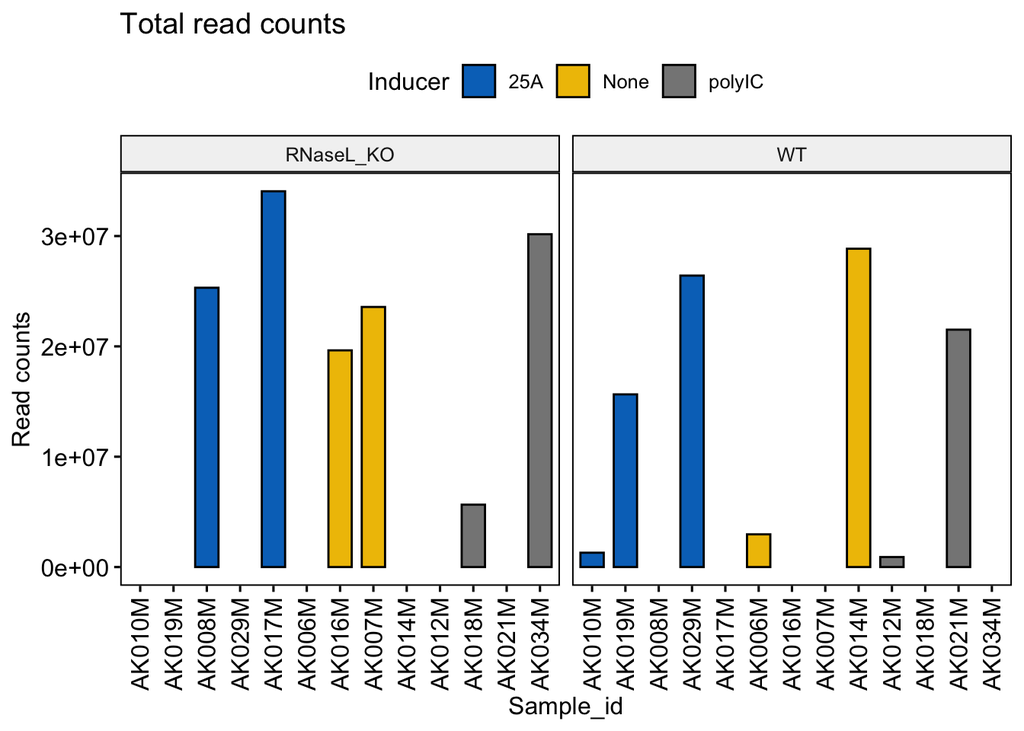

```r
# Plot total reads per sample using barchar
p <- ggbarplot(data = meta_one_exon,
          x = "Sample_id",
          y = "Read_counts",
          x.text.angle = 90,
          fill = "Inducer",
          title = "Total read counts",
          ylab = "Read counts",
          sort.by.groups = TRUE,
          palette = "jco",
          sort.val = "asc",
          facet.by = "Genotype")
ggsave("Plots/barplot_read_counts_exon.pdf", plot = p)
p
```

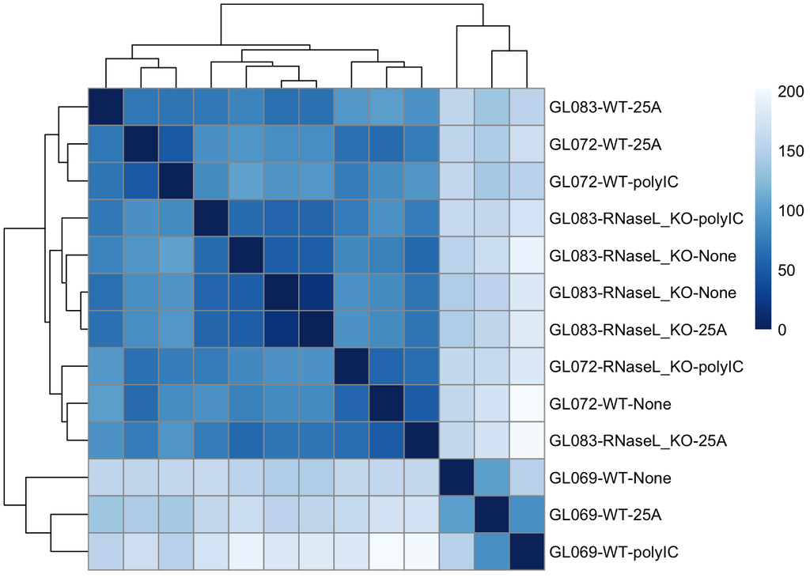

```r
# Normalize counts
rlog.one <- rlog(dds.one.exon, blind=FALSE)

# Keep genes with at least 20 reads total across samples
keep <- rowSums(counts(dds.one.exon)) >= 0 # Agnes wanted to keep all genes for the analysis
dds.one.exon <- dds.one.exon[keep,]

# Calculate distances between samples
sampleDists <- dist(t(assay(rlog.one)))

# Plot inter-sample distances
old.par <- par(no.readonly=T)

sampleDistMatrix <- as.matrix(sampleDists)
rownames(sampleDistMatrix) <- paste(rlog.one$Sequencing_pool, rlog.one$Genotype, rlog.one$Inducer, sep="-")
colnames(sampleDistMatrix) <- NULL
colors <- colorRampPalette( rev(brewer.pal(9, "Blues")) )(255)
pheatmap(sampleDistMatrix,
         clustering_distance_rows=sampleDists,
         clustering_distance_cols=sampleDists,
         col=colors)
```

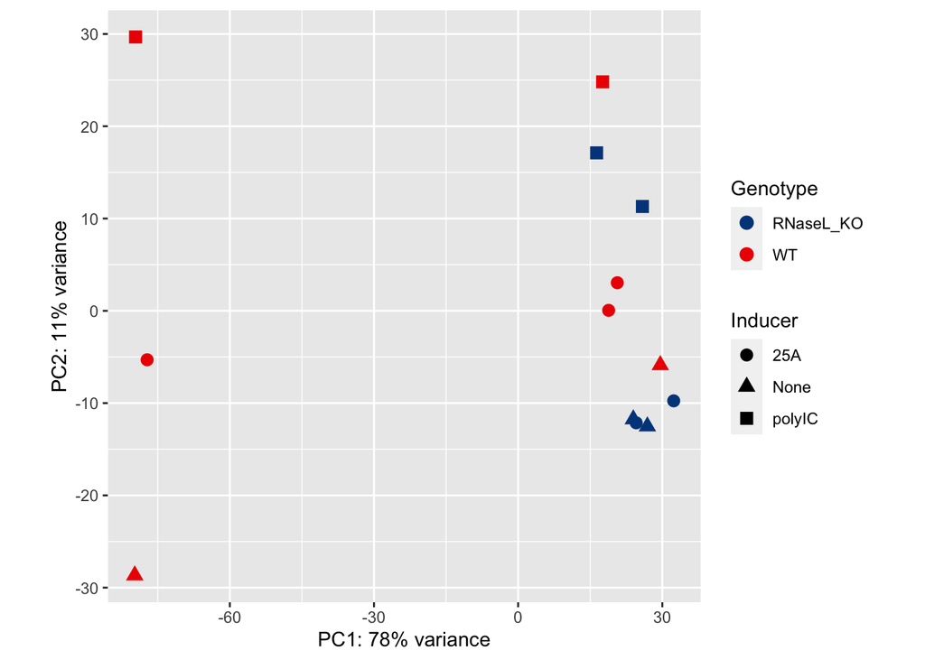

```r
# PCA
my_top_genes = 540

pcaData <- plotPCA(rlog.one, intgroup=c("Genotype", "Inducer"), returnData=TRUE, ntop = my_top_genes)
percentVar <- round(100 * attr(pcaData, "percentVar"))
y.coords = c(min(pcaData$PC1, pcaData$PC2), max(pcaData$PC1, pcaData$PC2))
x.coords = y.coords
p1 <- ggplot(pcaData, aes(PC1, PC2, color=Genotype, shape=Inducer)) +
  geom_point(size=3) + scale_color_lancet() +
  xlab(paste0("PC1: ",percentVar[1],"% variance")) +
  ylab(paste0("PC2: ",percentVar[2],"% variance")) +
  coord_fixed(ratio = (max(pcaData$PC1)-min(pcaData$PC1))/(max(pcaData$PC2)-min(pcaData$PC2)))

ggsave("Plots/pca_dataset_1_Induc_gt_exon.pdf", plot = p1)
p1
```

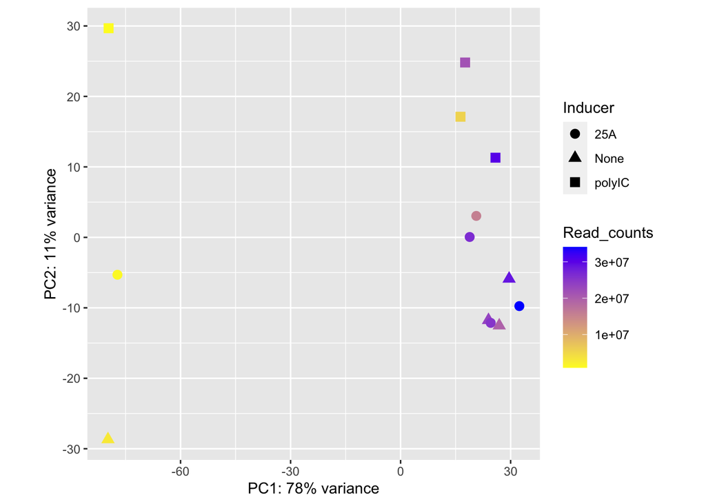

```r
pcaData <- plotPCA(rlog.one, intgroup=c("Read_counts", "Inducer"), returnData=TRUE, ntop = my_top_genes)
percentVar <- round(100 * attr(pcaData, "percentVar"))
p2 <- ggplot(pcaData, aes(PC1, PC2, color=Read_counts, shape=Inducer)) +
  geom_point(size=3) +
  xlab(paste0("PC1: ",percentVar[1],"% variance")) +
  ylab(paste0("PC2: ",percentVar[2],"% variance")) +
  coord_fixed(ratio = (max(pcaData$PC1)-min(pcaData$PC1))/(max(pcaData$PC2)-min(pcaData$PC2))) + scale_color_gradient2(high = "blue", mid = "yellow")

ggsave("Plots/pca_dataset_1_Induc_read_counts_exon.pdf", plot = p2)
p2
```

PCA plots indicate that samples separated on PC1 mostly by sequencing depth, within treatments and genotypes. This implies that sequencing depth has to be controlled for by including this factor in the design formula.